# Introduction to GitHub

# Projects

**Projects** in GitHub are a great way to organize your issues, set tasks, track your progress, and work with a team.

Click on the **Projects** tab at the top of the page.

[figure not shown]

Here you will see some information about Projects and all of the things you can do with them.

Click on the green downarrow next to the **Link a project** button on the right and select **New project**. Then click the green **New project** button.

[figure not shown]

If this is your first project, you should see a welcome window like the one below.

Click on the green **Jump right in** button.

[figure not shown]

You should now see a pop-up window for selecting a template with **Table** as the default.

[figure not shown]

Click on **Board** on the the left side and then click the green **Create** button.

[figure not shown]

You now have an untitled and empty project template with 3 gray boxes labeled **Todo**, **In Progress**, and **Done**.

[figure not shown]

Click on link at the top labeled **@username’s untitled project** (where username is your GitHub username) to bring up the project settings.

[figure not shown]

On the **Project settings** tab you can add a **name**, **description**, and **README**.

[figure not shown]

If you scroll down you will see the **Danger zone** where you can change the project visibility from private to public, close the project, or delete it.

[figure not shown]

Scroll back to the top and add a project name and description. Click the green **Save** button when you are done.

[figure not shown]

Now add some text to the **README** and click the green **Save** button when you are done.

Just as with other **README** sections, you can use Markdown for emphasis, lists, links, etc.

[figure not shown]

You can click on the **Manage access** link on the left to open up the project access tab. Here you can invite collaborators and set their role.

[figure not shown]

You can click on the **Status** link on the left to open up the field settings tab, which allows you to rename the column headings in your project or add other columns/fields as well.

[figure not shown]

Click on the left arrow in the upper left to return to your project’s main page.

[figure not shown]

Your project now has a better name.

[figure not shown]

Click on the **+ Add item** link at the bottom of the **Todo** field.

[figure not shown]

Click on the link to **Add item from repository**.

[figure not shown]

Select **testing** from the dropdown menu and then check the box next to the Issue you created earlier. Click the green **Add selected items** button when you are done.

[figure not shown]

Click on the **X** in the upper right to return to the project board.

[figure not shown]

You now have a new project with one todo item.

[figure not shown]

You can click on the issue title in the todo column to see its details. Click on the **X** in the upper right to close the preview window.

[figure not shown]

Now let’s address our todo items in our open issue.

Click-and-drag the issue from **Todo** to **In progress**.

[figure not shown]

Click in the **Search or jump to…** box at the top and select your testing repository to take you back there.

[figure not shown]

# Adding files and folders

Let’s address our open issue by adding some more content to our repo. To do so, we’ll work entirely within GitHub, but later in the course we’ll see how to add files from other locations like a local directory on your computer.

Click on the **Add file** button next to the green **Code** button and then select **Create new file**.

[figure not shown]

We now have a window for editing the file contents similar to the one we saw earlier when editing our `README.md` file. At the top left is a box where you can type in the name of the file you’d like to create.

[figure not shown]

If you’d like to create a new file within a new folder, you begin by typing the folder name followed by a `/` and then file name. You’ll notice that as soon as you type the `/` after the folder name that GitHub will automatically shift the text box to focus on the file name.

Create a new **R** script within a folder called `R`, and name it `00_testing.R`.

[figure not shown]

Navigate to the editing box and add some simple **R** code (it doesn’t matter what code you add).

[figure not shown]

When you are finished, scroll down to the **Commit new file** area, enter a brief but informative commit message, and click on the green **Commit new file** button.

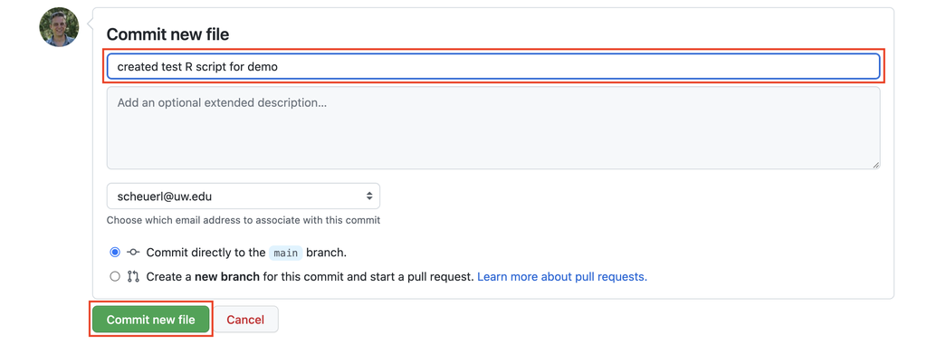

You can now see the contents of the new `/R` folder, which at the moment contains only the new `00_testing.R` file we just created.

In addition to the file name, you can see the commit message you used when committing the file (“created test R script for demo”) and when the file was committed (“now”).

[figure not shown]

You can click on the file name to inspect the file’s contents.

[figure not shown]

Click on the **Code** tab in the upper left, which will take you back the repo’s main page.

Here you can see our new `R` folder just above our existing `README.md` file.

[figure not shown]

Now let’s add a simple data file called `example_data.csv` and place it within a new folder called `data`.

Click on the **Add file** button next to the green **Code** button and then selecting **Create new file**. Type the folder name and file name in the box and add the following information in the editing box (you can copy and paste if you’d like):

```
last_name, first_name, role
Scheuerell, Mark, instructor
Adams, Mary, TA
Manion, Lance, student
```

[figure not shown]

When you are finished, scroll down to the **Commit new file** area, enter a brief but informative commit message, and click on the green **Commit new file** button.

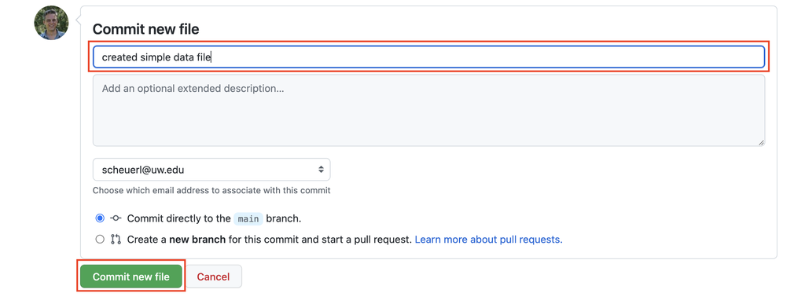

Just as when we created our **R** script within the `/R` folder, you can now see the new `example_data.csv` file we just created within the `/data` folder.

[figure not shown]

Click on the **Code** tab in the upper left, which will take you back the repo’s main page where you will see the new `/data` folder just below our existing `/R` folder.

[figure not shown]

# Closing an Issue

Now that we’ve added some new folders and files to our repo, let’s return to the Issue we created earlier and “close” it.

Click on the **Issues** tab on the top of the page to take you back to our open issue.

[figure not shown]

Click on the issue’s title, which will open it up and show you all of the details.

[figure not shown]

Check the boxes next to the 3 open tasks.

As you check off boxes next to tasks, GitHub will automatically update the number completed under the issue’s title.

[figure not shown]

At the bottom of the issue you will see a comment box with two buttons below it: **Close issue** and **Comment**. You don’t need to add a comment when closing an issue, but it’s often helpful to do so.

Add a comment and then click the **Close with comment** button.

[figure not shown]

You’ll now see that GitHub has marked the issue with a purple “Closed” label under the issue name.

[figure not shown]

Click on the **Issues** tab to return to the Issues page where GitHub informs you that there aren’t any open issues.

[figure not shown]

# Closing a project

Let’s return to our project and check on our progress now that we’ve closed the open issue.

Click on the **Projects** tab to take you back to the main Projects page where your project is listed and then click on the project name to open it back up.

[figure not shown]

GitHub automatically moved the open issue to the **Done** column when you closed it earlier.

[figure not shown]

# Endnote

**Congratulations!**

You’ve now successfully done the following:

- created a new repo on GitHub
- edited your `README.md` file
- created an issue
- created a project
- added some additional content to your repo
- closed an issue
- managed your project